# Homework 6

Yunting Chiu

2021-03-25

1. (**6.3**) A student stated: “Adding predictor variables to a regression model can never reduce $R^2$, so we should include all available predictor variables in the model.” Comment.
- Not really. If the model have a bigger $R^2$ value, which means the fitter is better. However, better fitting does not necessarily imply the fitted model is a useful one.
2. (**6.4**) Why is it not meaningful to attach a sign to the coefficient of multiple correlation R, although we do so for the coefficient of simple correlation $r_{12}$?
- The range of simple correlation coefficient is -1 to 1. The multiple correlation shows how any variable can be predicted by using a set of other variables. There will be several independent variables, each of which will have a different effect and a different direction. The multiple correlation coefficient will be more complicated than the simple one because the range is not limited to -1 to 1.
3. (**6.27**) In a small-scale regression study, the following data were obtained,

| Y | X1 | X2 |
| --- | --- | --- |
| 42.0 | 7.0 | 33.0 |
| 33.0 | 4.0 | 41.0 |
| 75.0 | 16.0 | 7.0 |
| 28.0 | 3.0 | 49.0 |
| 91.0 | 21.0 | 5.0 |
| 55.0 | 8.0 | 31.0 |

Assume the standard multiple regression model with independent normal error terms. Compute **b, e, H,** SSErr, $R^2$, $s^2_b$, $\hat{Y}$ for $X1$ = 10, $X2$ = 30. You can do the computations using software or by hand, although it would be lengthy to do them by hand.

- The first column is `scalar` (1, 1, 1, 1, 1, 1)

```r
scalar <- c(1, 1, 1, 1, 1, 1)
Y <-  c(42, 33, 75, 28, 91, 55)
X1 <-  c(7, 4, 16, 3, 21, 8)
X2 <-  c(33, 41, 7, 49, 5, 31)

# namely X is the matrix
X <- matrix(c(scalar, X1, X2), 6, 3, byrow = FALSE)
X
```

```
##      [,1] [,2] [,3]
## [1,]    1    7   33
## [2,]    1    4   41
## [3,]    1   16    7
## [4,]    1    3   49
## [5,]    1   21    5
## [6,]    1    8   31
```

## b: slope

$$\boldsymbol{\hat{\beta}} = \boldsymbol{(X^TX)}^{-1}\boldsymbol{(X^TY)}$$

```r
library(matlib)
b = inv(t(X) %*% X) %*% t(X) %*% Y
b
```

```
##            [,1]
## [1,] 33.9321020
## [2,]  2.7847707
## [3,] -0.2643979
```

## H: Hat

- H is called the hat-matrix (because it transforms $y$ to $\hat{y}$)
  $$H = X\boldsymbol{(X^TX)}^{-1}\boldsymbol{X^T}$$

```r
H = X %*% inv(t(X) %*% X) %*% t(X)
H
```

```
##             [,1]        [,2]        [,3]       [,4]        [,5]       [,6]
## [1,]  0.23143639  0.25168006  0.21178834  0.1488734 -0.05475455 0.21099418
## [2,]  0.25168006  0.31240977  0.09437951  0.2662835 -0.14787196 0.22314063
## [3,]  0.21178834  0.09437951  0.70442097 -0.3191731  0.10446756 0.20412257
## [4,]  0.14887339  0.26628346 -0.31917314  0.6142637  0.14143589 0.14834214
## [5,] -0.05475455 -0.14787196  0.10446756  0.1414359  0.94040059 0.01632796
## [6,]  0.21099418  0.22314063  0.20412257  0.1483421  0.01632796 0.19708945
```

## e: resuduals

$$e = Y -\hat{Y} = Y - H * Y$$

```r
e <- Y - H %*% Y
e
```

```
##             [,1]
## [1,] -2.70036663
## [2,] -1.23087135
## [3,] -1.63764825
## [4,] -1.33091751
## [5,] -0.09029763
## [6,]  6.98606687
```

## SSErr

$$SSE = e^T * e$$

- **SSErr** is error sum of squares.

```r
SSE <- t(e) %*% e
SSE
```

```
##          [,1]
## [1,] 62.07354
```

```r
# SSErr <- sum(e^2)
# SSErr
```

## **$R^2$**

$$R^2 = \frac{SSRegression}{SSTotal} = 1 - \frac{SSError}{SSTotal}$$

```r
SST <- sum((Y - mean(Y))^2) # total sum of squares
SST
```

```
## [1] 3072
```

```r
R2 <- 1 - SSE/SST # R^2
R2
```

```
##           [,1]
## [1,] 0.9797938
```

## **$s^2_b$**

$$MSE = \frac{SSE}{n-2}$$

```r
MSE <- SSE/ (6-2)
MSE
```

```
##          [,1]
## [1,] 15.51839
```

$$S^2\{b\} = MSE(X^T * X)^{-1}$$

```r
s2b <- MSE[1,1] * inv(t(X) %*% X)
s2b
```

```
##           [,1]        [,2]        [,3]
## [1,] 536.60338 -25.6191888 -10.1962033
## [2,] -25.61919   1.2462499   0.4830506
## [3,] -10.19620   0.4830506   0.1968509
```

## E{Y|X1 = 10, X2 = 30}

- The equation below is an unbiased estimator of estimated of Y_n.
  $$\hat{Y}_h = X_h^T * b$$

```r
Xone <- c(1, 10, 30)
yhat <- t(Xone) %*% b
yhat
```

```
##          [,1]
## [1,] 53.84787
```

- Reference:
  - https://stats.stackexchange.com/questions/352130/converting-the-beta-coefficient-from-matrix-to-scalar-notation-in-ols-regression
  - https://www.stat.cmu.edu/~cshalizi/mreg/15/lectures/13/lecture-13.pdf
  - http://fs2.american.edu/baron/www/Handouts/review%20-%20regression.pdf
4. (Computer project, **#6.5—#6.8**) Dataset “Brand preference” is available on our Blackboard, on http://statweb.lsu.edu/EXSTWeb/StatLab/DataSets/NKNWData/CH06PR05.txt, and here:

```r
brand <- read.table("./data/CH06PR05.txt")
brand %>%
  rename(brand = "V1", moisture = "V2", sweetness = "V3") -> brand
brand
```

| brand | moisture | sweetness |
| --- | --- | --- |
| 64 | 4 | 2 |
| 73 | 4 | 4 |
| 61 | 4 | 2 |
| 76 | 4 | 4 |
| 72 | 6 | 2 |
| 80 | 6 | 4 |
| 71 | 6 | 2 |
| 83 | 6 | 4 |
| 83 | 8 | 2 |
| 89 | 8 | 4 |

[output cut: 6 more lines]

```r
# Y, X1, X2
```

It was collected to study the relation between degree of brand liking (Y ) and moisture content (X1) and sweetness (X2) of the product. (a) Fit a regression model to these data and state the estimated regression function. Interpret b1.
$$\hat{Y} = 37.6500 + 4.4250X1 + 4.3750X2$$
- The slope $b_1$ is 4.425, meaning that the mean response `degree of brand liking` is increase by 4.425 with 1 unit increase of `moisture` when `sweetness` is held constant.

```r
reg <- lm(brand ~ moisture + sweetness, data = brand)
summary(reg)
```

```
##
## Call:
## lm(formula = brand ~ moisture + sweetness, data = brand)
##
## Residuals:
##    Min     1Q Median     3Q    Max
## -4.400 -1.762  0.025  1.587  4.200
##
## Coefficients:
##             Estimate Std. Error t value Pr(>|t|)
## (Intercept)  37.6500     2.9961  12.566 1.20e-08 ***
## moisture      4.4250     0.3011  14.695 1.78e-09 ***
## sweetness     4.3750     0.6733   6.498 2.01e-05 ***
## ---
## Signif. codes:  0 '***' 0.001 '**' 0.01 '*' 0.05 '.' 0.1 ' ' 1
##
## Residual standard error: 2.693 on 13 degrees of freedom
## Multiple R-squared:  0.9521, Adjusted R-squared:  0.9447
## F-statistic: 129.1 on 2 and 13 DF,  p-value: 2.658e-09
```

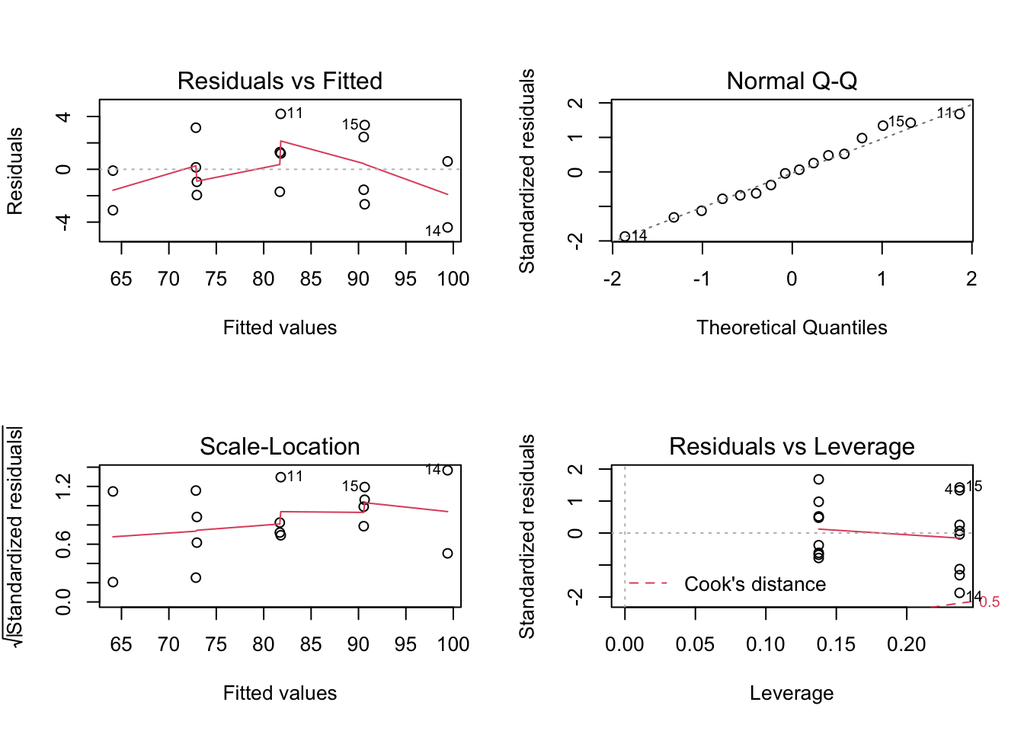

```r
par(mfrow = c(2, 2))
plot(reg)
```

3. Test homoscedasticity.
- With a high p-value 0.42877, there is no evidence of non-constant variance.

```r
library(car)
ncvTest(reg)
```

```
## Non-constant Variance Score Test
## Variance formula: ~ fitted.values
## Chisquare = 0.6261627, Df = 1, p = 0.42877
```

4. Conduct a formal lack of fit test.
- We conclude that the p-value is 0.3843, we fail to reject the H0, meaning that there is no evidence of lack of fit. Thus, there should be no significant difference in error between estimates from the reduced (`reg`) model and the full model.
- Reference: https://stats.stackexchange.com/questions/339331/difference-between-full-model-and-reduced-model-in-one-way-anova
  $$Full Model: Y_{ij} = \mu_j + e_{ij}$$
  $$Reduced Model: Y_{ij} = \mu + e_{ij}$$

```r
full <- lm(brand ~ as.factor(moisture) + as.factor(sweetness), data = brand)
anova(reg, full)
```

|  | Res.Df | RSS | Df | Sum of Sq | F | Pr(>F) |
| --- | --- | --- | --- | --- | --- | --- |
| 1 | 13 | 94.30 | NA | NA | NA | NA |
| 2 | 11 | 79.25 | 2 | 15.05 | 1.044479 | 0.38431 |

```r
anova(full, reg)
```

|  | Res.Df | RSS | Df | Sum of Sq | F | Pr(>F) |
| --- | --- | --- | --- | --- | --- | --- |
| 1 | 11 | 79.25 | NA | NA | NA | NA |
| 2 | 13 | 94.30 | -2 | -15.05 | 1.044479 | 0.38431 |

5. Test whether the proposed linear regression model is significant. What do the results of the ANOVA F-test imply about the slopes?
- Let we set H0: $\beta1 = \beta2 = 0$ vs Ha: $\beta1 \neq0$ or $\beta2 \neq0$ at least.
- We found both p-values ($\beta1$ and $\beta2$) are smaller than significant level, implying that we are in favor of Ha. Reference: https://www.researchgate.net/post/Is_the_null_and_alternative_hypothesis_for_this_multiple_linear_regression_analysis_correct

```r
anova(reg)
```

|  | Df | Sum Sq | Mean Sq | F value | Pr(>F) |
| --- | --- | --- | --- | --- | --- |
| moisture | 1 | 1566.45 | 1566.450000 | 215.94751 | 1.778029e-09 |
| sweetness | 1 | 306.25 | 306.250000 | 42.21898 | 2.011047e-05 |
| Residuals | 13 | 94.30 | 7.253846 | NA | NA |

```r
summary(reg)
```

```
##
## Call:
## lm(formula = brand ~ moisture + sweetness, data = brand)
##
## Residuals:
##    Min     1Q Median     3Q    Max
## -4.400 -1.762  0.025  1.587  4.200
##
## Coefficients:
##             Estimate Std. Error t value Pr(>|t|)
## (Intercept)  37.6500     2.9961  12.566 1.20e-08 ***
## moisture      4.4250     0.3011  14.695 1.78e-09 ***
## sweetness     4.3750     0.6733   6.498 2.01e-05 ***
## ---
## Signif. codes:  0 '***' 0.001 '**' 0.01 '*' 0.05 '.' 0.1 ' ' 1
##
## Residual standard error: 2.693 on 13 degrees of freedom
## Multiple R-squared:  0.9521, Adjusted R-squared:  0.9447
## F-statistic: 129.1 on 2 and 13 DF,  p-value: 2.658e-09
```

6. Estimate both slopes simultaneously using the Bonferroni procedure with at least a 99 percent confidence level.
- The Bonferroni test is a statistical test used to reduce the instance of a false positive (typr 1 error)
- To preform the Bonferroni correction, we need to divide the $\alpha$ level by the number of tests that being executed.
- We need to test 2 slopes, and the significance level is 0.01. So, 0.01/2 = 0.005. Throughout the Bonferroni procedure, the adjusted $alpha$ level is 0.005 with two slopes.
- Reference: https://toptipbio.com/bonferroni-correction-method/

```r
confint(reg, level = (1-0.005))
```

```
##                0.25 %   99.75 %
## (Intercept) 27.545738 47.754262
## moisture     3.409483  5.440517
## sweetness    2.104236  6.645764
```

7. Report R2 and adjusted R2. How are they interpreted here?
- It means that 95 % of the variation in the `brand` is explained by the `moisture` and `sweetness` independent variables.

```r
summary(reg)$r.square
```

```
## [1] 0.952059
```

- It means that 94 % of the variation in the `brand` is explained by model addition that are significant of `moisture` and `sweetness`.

```r
summary(reg)$adj.r.square
```

```
## [1] 0.9446834
```

- Reference: https://discuss.analyticsvidhya.com/t/difference-between-r-square-and-adjusted-r-square/264/2
8. Calculate the squared correlation coefficient between $Yi$ and $\hat{Y}$. Compare with part (g).
- The squared correlation coefficient between $Yi$ and $\hat{Y}$ is $R^2$, which is 0.952059.
1. Obtain a 99% confidence interval for E(Y) when X1 = 5 and X2 = 4. Interpret it.
- We have 99 % confidence to conclude that the **mean** of `degree of brand liking` is between 73.88111 to 80.66889 when the `moisture content` is 5 and the `sweetness of the product` is 4.

```r
predict(reg, tibble(moisture = 5, sweetness = 4), interval = "confidence", level = 0.99)
```

```
##      fit      lwr      upr
## 1 77.275 73.88111 80.66889
```

```r
predict(reg, tibble(moisture = 5, sweetness = 4), interval = "prediction", level = 0.99)
```

```
##      fit      lwr      upr
## 1 77.275 68.48077 86.06923
```

5. (**# 6.26, Stat-615 only**) Show that the squared sample correlation coefficient between $Y$ and $\hat Y$ equals $R^2$.

Remark. Now you can check if you did #3h correctly.
Hints. First, show that the sample averages of Yi and Ybi are the same. Then, write the sample correlation coefficient between $Y$ and $\hat Y$ as
$$r_{Y\widehat{Y}} = \frac{\sum
(Y_i-\overline{Y})(\widehat{Y}_i-\overline{Y})}{\sqrt{\sum
(Y_i-\overline{Y})^2\sum(\widehat{Y}_i-\overline{Y})^2}}
= \frac{\sum
(\widehat{Y}_i-\overline{Y}+Y_i-\widehat{Y}_i)(\widehat{Y}_i-\overline{Y})}{\sqrt{\sum
(Y_i-\overline{Y})^2\sum(\widehat{Y}_i-\overline{Y})^2}}$$
and use known properties of residuals $\sum e_i=0$, $\sum X_{ij} e_i=0$, $\sum \widehat{Y}_i e_i=0$. }}

[figure not shown]

- Reference: https://stats.stackexchange.com/questions/187734/relationship-between-r2-and-correlation-coefficient